# Week 2 - Preprocessing, part 2

# 1. Lesson: None

# 2. Weekly graph question

The Storytelling With Data book mentions planning on a "Who, What, and How" for your data story. Write down a possible Who, What, and How for your data, using the ideas in the book.

# 3. Homework - work with your own data

```python
import pandas as pd
import numpy as np
from datetime import datetime, timedelta

import matplotlib.pyplot as plt
```

```python
df = pd.read_csv('..\SID.tsv',sep='\t', engine='python')
data5 = pd.read_csv('..\data5.csv', sep=',', engine='python')
dcd25 = pd.read_csv('..\DCD_2025.tsv', sep='\t', engine='python')
```

### CHECKLIST

This week, you will do the same types of exercises as last week, but you should use your chosen datasets that someone in your class found last semester. (They likely will not be the particular datasets that you found yourself.)

### Here are some types of analysis you can do Use Google, documentation, and ChatGPT to help you:

- Summarize the datasets using info() and describe()
- Are there any duplicate rows?
- Are there any duplicate values in a given column (when this would be inappropriate?)
- What are the mean, median, and mode of each column?
- Are there any missing or null values?
  - Do you want to fill in the missing value with a mean value? A value of your choice? Remove that row?
- Identify any other inconsistent data (e.g. someone seems to be taking an action before they are born.)
- Encode any categorical variables (e.g. with one-hot encoding.)

### Conclusions:

- Are the data usable? If not, find some new data!
- Do you need to modify or correct the data in some way?
- Is there any class imbalance? (Categories that have many more items than other categories).

#### summarize the data

```python
df.head(10)
```

|  | year | stabbr | state_name | statefip | region4 | region9 | effort | inc_effort | predicted_fedrevpp0_ | predicted_fedrevpp10_ | ... | inc_gap130_ratio | coverage | state_chartershare | inc_pubsch | inc_nonpubsch | pubprv_incratio | case | citation | ruling | casetype |
| --- | --- | --- | --- | --- | --- | --- | --- | --- | --- | --- | --- | --- | --- | --- | --- | --- | --- | --- | --- | --- | --- |
| 0 | 2022 | AL | Alabama | 1 | South | East South Central | 0.036929 | 0.039076 | 1108.6490 | 1668.692 | ... | 0.187758 | 0.825960 | 0.004447 | 94260.31 | 130562.7 | 0.721955 | NaN | NaN | NaN | NaN |
| 1 | 2022 | AK | Alaska | 2 | West | Pacific | 0.043423 | 0.056036 | 1776.7740 | 3541.949 | ... | 0.225224 | 0.821983 | 0.064936 | 109327.70 | 109224.8 | 1.000942 | NaN | NaN | NaN | NaN |
| 2 | 2022 | AZ | Arizona | 4 | West | Mountain | 0.024628 | 0.026759 | 1067.8530 | 1859.725 | ... | 0.190693 | 0.881690 | 0.351399 | 118109.90 | 137257.1 | 0.860501 | NaN | NaN | NaN | NaN |
| 3 | 2022 | AR | Arkansas | 5 | South | West South Central | 0.038394 | 0.037691 | 1381.2480 | 2004.317 | ... | 0.206366 | 0.859202 | 0.097590 | 90338.76 | 102996.4 | 0.877106 | NaN | NaN | NaN | NaN |
| 4 | 2022 | CA | California | 6 | West | Pacific | 0.030721 | 0.036699 | 1214.3630 | 2042.963 | ... | 0.155518 | 0.882351 | 0.153031 | 141409.50 | 225058.4 | 0.628324 | NaN | NaN | NaN | NaN |
| 5 | 2022 | CO | Colorado | 8 | West | Mountain | 0.028565 | 0.031449 | 872.7088 | 1584.716 | ... | 0.136332 | 0.871865 | 0.157807 | 153223.20 | 191002.7 | 0.802205 | NaN | NaN | NaN | NaN |
| 6 | 2022 | CT | Connecticut | 9 | Northeast | New England | 0.036377 | 0.037655 | 1034.8150 | 1823.980 | ... | 0.111852 | 0.883713 | 0.023871 | 181087.50 | 307426.4 | 0.589043 | NaN | NaN | NaN | NaN |
| 7 | 2022 | DE | Delaware | 10 | South | South Atlantic | 0.029588 | 0.041724 | 1573.6370 | 2505.769 | ... | 0.173519 | 0.860197 | 0.151148 | 130153.20 | 149282.0 | 0.871861 | NaN | NaN | NaN | NaN |
| 8 | 2022 | DC | District of Columbia | 11 | South | South Atlantic | 0.022555 | 0.055172 | NaN | NaN | ... | 0.082082 | 0.764825 | 0.766227 | 202162.30 | 372437.9 | 0.542808 | NaN | NaN | NaN | NaN |
| 9 | 2022 | FL | Florida | 12 | South | South Atlantic | 0.025701 | 0.025563 | 1467.9560 | 2057.146 | ... | 0.178857 | 0.823513 | 0.128460 | 113978.10 | 161580.6 | 0.705395 | NaN | NaN | NaN | NaN |

10 rows × 124 columns

```python
data5.head(10)
```

|  | Marital status | Application mode | Application order | Course | AttendanceTime | Previous qualification | Previous qualification (grade) | Nacionality | Mother's qualification | Father's qualification | ... | Curricular units 2nd sem (credited) | Curricular units 2nd sem (enrolled) | Curricular units 2nd sem (evaluations) | Curricular units 2nd sem (approved) | Curricular units 2nd sem (grade) | Curricular units 2nd sem (without evaluations) | Unemployment rate | Inflation rate | GDP | Target |
| --- | --- | --- | --- | --- | --- | --- | --- | --- | --- | --- | --- | --- | --- | --- | --- | --- | --- | --- | --- | --- | --- |
| 0 | 1 | 17 | 5 | 171 | 1 | 1 | 122.0 | 1 | 19 | 12 | ... | 0 | 0 | 0 | 0 | 0.000000 | 0 | 10.8 | 1.4 | 1.74 | 0 |
| 1 | 1 | 15 | 1 | 9254 | 1 | 1 | 160.0 | 1 | 1 | 3 | ... | 0 | 6 | 6 | 6 | 13.666667 | 0 | 13.9 | -0.3 | 0.79 | 1 |
| 2 | 1 | 1 | 5 | 9070 | 1 | 1 | 122.0 | 1 | 37 | 37 | ... | 0 | 6 | 0 | 0 | 0.000000 | 0 | 10.8 | 1.4 | 1.74 | 0 |
| 3 | 1 | 17 | 2 | 9773 | 1 | 1 | 122.0 | 1 | 38 | 37 | ... | 0 | 6 | 10 | 5 | 12.400000 | 0 | 9.4 | -0.8 | -3.12 | 1 |
| 4 | 2 | 39 | 1 | 8014 | 0 | 1 | 100.0 | 1 | 37 | 38 | ... | 0 | 6 | 6 | 6 | 13.000000 | 0 | 13.9 | -0.3 | 0.79 | 1 |
| 5 | 2 | 39 | 1 | 9991 | 0 | 19 | 133.1 | 1 | 37 | 37 | ... | 0 | 5 | 17 | 5 | 11.500000 | 5 | 16.2 | 0.3 | -0.92 | 1 |
| 6 | 1 | 1 | 1 | 9500 | 1 | 1 | 142.0 | 1 | 19 | 38 | ... | 0 | 8 | 8 | 8 | 14.345000 | 0 | 15.5 | 2.8 | -4.06 | 1 |
| 7 | 1 | 18 | 4 | 9254 | 1 | 1 | 119.0 | 1 | 37 | 37 | ... | 0 | 5 | 5 | 0 | 0.000000 | 0 | 15.5 | 2.8 | -4.06 | 0 |
| 8 | 1 | 1 | 3 | 9238 | 1 | 1 | 137.0 | 62 | 1 | 1 | ... | 0 | 6 | 7 | 6 | 14.142857 | 0 | 16.2 | 0.3 | -0.92 | 1 |
| 9 | 1 | 1 | 1 | 9238 | 1 | 1 | 138.0 | 1 | 1 | 19 | ... | 0 | 6 | 14 | 2 | 13.500000 | 0 | 8.9 | 1.4 | 3.51 | 0 |

10 rows × 37 columns

```python
dcd25.head(10)
```

|  | year | leaid | district | state_name | stabbr | ppcstot | predcost | fundinggap | outcomegap | enroll | ... | Unnamed: 55 | Unnamed: 56 | Unnamed: 57 | Unnamed: 58 | Unnamed: 59 | Unnamed: 60 | Unnamed: 61 | Unnamed: 62 | Unnamed: 63 | Unnamed: 64 |
| --- | --- | --- | --- | --- | --- | --- | --- | --- | --- | --- | --- | --- | --- | --- | --- | --- | --- | --- | --- | --- | --- |
| 0 | 2022 | 100005 | ALBERTVILLE CITY | Alabama | AL | 10266 | 13358 | -3092 | NaN | 5956 | ... | NaN | NaN | NaN | NaN | NaN | NaN | NaN | NaN | NaN | NaN |
| 1 | 2022 | 100030 | ALEXANDER CITY | Alabama | AL | 12566 | 19503 | -6937 | NaN | 2927 | ... | NaN | NaN | NaN | NaN | NaN | NaN | NaN | NaN | NaN | NaN |
| 2 | 2022 | 100060 | ANDALUSIA CITY | Alabama | AL | 11436 | 17564 | -6128 | NaN | 1862 | ... | NaN | NaN | NaN | NaN | NaN | NaN | NaN | NaN | NaN | NaN |
| 3 | 2022 | 100090 | ANNISTON CITY | Alabama | AL | 13896 | 33488 | -19592 | NaN | 1908 | ... | NaN | NaN | NaN | NaN | NaN | NaN | NaN | NaN | NaN | NaN |
| 4 | 2022 | 100100 | ARAB CITY | Alabama | AL | 10682 | 9721 | 961 | NaN | 2645 | ... | NaN | NaN | NaN | NaN | NaN | NaN | NaN | NaN | NaN | NaN |
| 5 | 2022 | 100120 | ATHENS CITY | Alabama | AL | 10655 | 13178 | -2523 | NaN | 4788 | ... | NaN | NaN | NaN | NaN | NaN | NaN | NaN | NaN | NaN | NaN |
| 6 | 2022 | 100180 | ATTALLA CITY | Alabama | AL | 11028 | 18665 | -7637 | NaN | 1523 | ... | NaN | NaN | NaN | NaN | NaN | NaN | NaN | NaN | NaN | NaN |
| 7 | 2022 | 100210 | AUBURN CITY | Alabama | AL | 10977 | 11255 | -278 | NaN | 9395 | ... | NaN | NaN | NaN | NaN | NaN | NaN | NaN | NaN | NaN | NaN |
| 8 | 2022 | 100240 | AUTAUGA COUNTY | Alabama | AL | 10270 | 12590 | -2320 | NaN | 9008 | ... | NaN | NaN | NaN | NaN | NaN | NaN | NaN | NaN | NaN | NaN |
| 9 | 2022 | 100270 | BALDWIN COUNTY | Alabama | AL | 11999 | 11493 | 506 | NaN | 31812 | ... | NaN | NaN | NaN | NaN | NaN | NaN | NaN | NaN | NaN | NaN |

10 rows × 65 columns

```python
df.describe()
```

|  | year | statefip | effort | inc_effort | predicted_fedrevpp0_ | predicted_fedrevpp10_ | predicted_fedrevpp20_ | predicted_fedrevpp30_ | fairness_fedrevpp | predicted_strevpp0_ | ... | ftotinc_over185pov | ftotinc_under130pov | ftotinc_over130pov | inc_gap185_ratio | inc_gap130_ratio | coverage | state_chartershare | inc_pubsch | inc_nonpubsch | pubprv_incratio |
| --- | --- | --- | --- | --- | --- | --- | --- | --- | --- | --- | --- | --- | --- | --- | --- | --- | --- | --- | --- | --- | --- |
| count | 1530.000000 | 1530.000000 | 862.000000 | 1219.000000 | 1469.000000 | 1469.000000 | 1469.000000 | 1469.000000 | 1469.000000 | 1469.000000 | ... | 1173.000000 | 1173.000000 | 1173.000000 | 1173.000000 | 1173.000000 | 1173.000000 | 1122.000000 | 1173.000000 | 1173.000000 | 1173.000000 |
| mean | 2007.500000 | 28.960784 | 0.036511 | 0.043408 | 413.420982 | 692.790212 | 1206.766303 | 2189.739187 | 6.325168 | 5200.001802 | ... | 109781.244672 | 18881.741091 | 99870.214322 | 0.248388 | 0.195499 | 0.870169 | 0.043592 | 84184.277587 | 117335.307451 | 0.734698 |
| std | 8.658271 | 15.681961 | 0.006322 | 0.007135 | 358.256173 | 552.528758 | 968.487414 | 1962.443580 | 4.232710 | 4429.494386 | ... | 27875.971726 | 3237.280708 | 26398.185928 | 0.039025 | 0.032970 | 0.034853 | 0.085533 | 24617.219172 | 37960.625473 | 0.139107 |
| min | 1993.000000 | 1.000000 | 0.015759 | 0.025232 | 53.021740 | 93.929260 | 135.745800 | 196.178800 | 0.625949 | 137.849900 | ... | 64123.150000 | 11489.350000 | 55660.230000 | 0.088856 | 0.056240 | 0.726157 | 0.000000 | 39960.210000 | 48956.750000 | 0.252707 |
| 25% | 2000.000000 | 16.000000 | 0.031993 | 0.038909 | 194.514800 | 359.645100 | 678.812000 | 1174.416000 | 3.534862 | 2812.058000 | ... | 90088.290000 | 16368.580000 | 81310.580000 | 0.229800 | 0.177963 | 0.850274 | 0.000951 | 66619.660000 | 93201.330000 | 0.640813 |
| 50% | 2007.500000 | 29.000000 | 0.036168 | 0.042800 | 322.614800 | 570.995500 | 973.945200 | 1645.171000 | 5.177474 | 4150.581000 | ... | 105133.500000 | 18792.110000 | 94637.270000 | 0.251981 | 0.199773 | 0.875658 | 0.020631 | 79034.990000 | 110297.500000 | 0.721956 |
| 75% | 2015.000000 | 42.000000 | 0.040870 | 0.047228 | 476.445200 | 798.407200 | 1338.598000 | 2461.689000 | 7.821515 | 6106.841000 | ... | 125603.800000 | 21233.220000 | 114190.600000 | 0.272399 | 0.216515 | 0.893712 | 0.053254 | 97191.840000 | 133216.700000 | 0.810311 |
| max | 2022.000000 | 56.000000 | 0.055217 | 0.073341 | 4470.387000 | 8423.760000 | 15873.290000 | 29910.780000 | 49.728310 | 55763.150000 | ... | 252619.500000 | 30517.150000 | 239824.800000 | 0.402794 | 0.291931 | 0.950709 | 0.766227 | 202162.300000 | 372437.900000 | 1.393209 |

8 rows × 116 columns

```python
data5.describe()
```

|  | Marital status | Application mode | Application order | Course | AttendanceTime | Previous qualification | Previous qualification (grade) | Nacionality | Mother's qualification | Father's qualification | ... | Curricular units 2nd sem (credited) | Curricular units 2nd sem (enrolled) | Curricular units 2nd sem (evaluations) | Curricular units 2nd sem (approved) | Curricular units 2nd sem (grade) | Curricular units 2nd sem (without evaluations) | Unemployment rate | Inflation rate | GDP | Target |
| --- | --- | --- | --- | --- | --- | --- | --- | --- | --- | --- | --- | --- | --- | --- | --- | --- | --- | --- | --- | --- | --- |
| count | 4424.000000 | 4424.000000 | 4424.000000 | 4424.000000 | 4424.000000 | 4424.000000 | 4424.000000 | 4424.000000 | 4424.000000 | 4424.000000 | ... | 4424.000000 | 4424.000000 | 4424.000000 | 4424.000000 | 4424.000000 | 4424.000000 | 4424.000000 | 4424.000000 | 4424.000000 | 4424.000000 |
| mean | 1.178571 | 18.669078 | 1.727848 | 8856.642631 | 0.890823 | 4.577758 | 132.613314 | 1.873192 | 19.561935 | 22.275316 | ... | 0.541817 | 6.232143 | 8.063291 | 4.435805 | 10.230206 | 0.150316 | 11.566139 | 1.228029 | 0.001969 | 0.858273 |
| std | 0.605747 | 17.484682 | 1.313793 | 2063.566416 | 0.311897 | 10.216592 | 13.188332 | 6.914514 | 15.603186 | 15.343108 | ... | 1.918546 | 2.195951 | 3.947951 | 3.014764 | 5.210808 | 0.753774 | 2.663850 | 1.382711 | 2.269935 | 0.693326 |
| min | 1.000000 | 1.000000 | 0.000000 | 33.000000 | 0.000000 | 1.000000 | 95.000000 | 1.000000 | 1.000000 | 1.000000 | ... | 0.000000 | 0.000000 | 0.000000 | 0.000000 | 0.000000 | 0.000000 | 7.600000 | -0.800000 | -4.060000 | 0.000000 |
| 25% | 1.000000 | 1.000000 | 1.000000 | 9085.000000 | 1.000000 | 1.000000 | 125.000000 | 1.000000 | 2.000000 | 3.000000 | ... | 0.000000 | 5.000000 | 6.000000 | 2.000000 | 10.750000 | 0.000000 | 9.400000 | 0.300000 | -1.700000 | 0.000000 |
| 50% | 1.000000 | 17.000000 | 1.000000 | 9238.000000 | 1.000000 | 1.000000 | 133.100000 | 1.000000 | 19.000000 | 19.000000 | ... | 0.000000 | 6.000000 | 8.000000 | 5.000000 | 12.200000 | 0.000000 | 11.100000 | 1.400000 | 0.320000 | 1.000000 |
| 75% | 1.000000 | 39.000000 | 2.000000 | 9556.000000 | 1.000000 | 1.000000 | 140.000000 | 1.000000 | 37.000000 | 37.000000 | ... | 0.000000 | 7.000000 | 10.000000 | 6.000000 | 13.333333 | 0.000000 | 13.900000 | 2.600000 | 1.790000 | 1.000000 |
| max | 6.000000 | 57.000000 | 9.000000 | 9991.000000 | 1.000000 | 43.000000 | 190.000000 | 109.000000 | 44.000000 | 44.000000 | ... | 19.000000 | 23.000000 | 33.000000 | 20.000000 | 18.571429 | 12.000000 | 16.200000 | 3.700000 | 3.510000 | 2.000000 |

8 rows × 37 columns

```python
dcd25.describe()
```

|  | year | leaid | ppcstot | predcost | fundinggap | outcomegap | enroll | pov | iep | ell | ... | Unnamed: 55 | Unnamed: 56 | Unnamed: 57 | Unnamed: 58 | Unnamed: 59 | Unnamed: 60 | Unnamed: 61 | Unnamed: 62 | Unnamed: 63 | Unnamed: 64 |
| --- | --- | --- | --- | --- | --- | --- | --- | --- | --- | --- | --- | --- | --- | --- | --- | --- | --- | --- | --- | --- | --- |
| count | 171004.000000 | 1.710040e+05 | 171004.000000 | 171004.000000 | 171004.000000 | 113898.000000 | 1.710040e+05 | 171004.000000 | 165144.000000 | 169718.000000 | ... | 0.0 | 0.0 | 0.0 | 0.0 | 0.0 | 0.0 | 0.0 | 0.0 | 0.0 | 0.0 |
| mean | 2015.439481 | 3.011392e+06 | 12526.833062 | 12027.397002 | 499.437124 | 0.024471 | 3.857395e+03 | 0.170887 | 0.144129 | 0.048094 | ... | NaN | NaN | NaN | NaN | NaN | NaN | NaN | NaN | NaN | NaN |
| std | 4.029447 | 1.469648e+06 | 4758.813796 | 5634.384389 | 6892.118612 | 0.353254 | 1.509732e+04 | 0.094973 | 0.045834 | 0.088772 | ... | NaN | NaN | NaN | NaN | NaN | NaN | NaN | NaN | NaN | NaN |
| min | 2009.000000 | 1.000050e+05 | 251.000000 | 3802.000000 | -78683.000000 | -3.797798 | 1.000000e+02 | 0.000000 | 0.000000 | 0.000000 | ... | NaN | NaN | NaN | NaN | NaN | NaN | NaN | NaN | NaN | NaN |
| 25% | 2012.000000 | 1.807980e+06 | 9324.000000 | 8553.000000 | -2536.000000 | -0.194690 | 5.120000e+02 | 0.098712 | 0.114053 | 0.002303 | ... | NaN | NaN | NaN | NaN | NaN | NaN | NaN | NaN | NaN | NaN |
| 50% | 2015.000000 | 3.028770e+06 | 11169.000000 | 10626.000000 | 504.500000 | 0.025774 | 1.267000e+03 | 0.156109 | 0.140705 | 0.012774 | ... | NaN | NaN | NaN | NaN | NaN | NaN | NaN | NaN | NaN | NaN |
| 75% | 2019.000000 | 4.103990e+06 | 14358.000000 | 13725.000000 | 3589.000000 | 0.240266 | 3.209250e+03 | 0.226869 | 0.170455 | 0.050042 | ... | NaN | NaN | NaN | NaN | NaN | NaN | NaN | NaN | NaN | NaN |
| max | 2022.000000 | 5.606240e+06 | 83114.000000 | 98479.000000 | 62435.000000 | 1.657541 | 1.014020e+06 | 1.000000 | 1.379532 | 0.956740 | ... | NaN | NaN | NaN | NaN | NaN | NaN | NaN | NaN | NaN | NaN |

8 rows × 62 columns

```python
df.info()
```

```
<class 'pandas.core.frame.DataFrame'>
RangeIndex: 1530 entries, 0 to 1529
Columns: 124 entries, year to casetype
dtypes: float64(114), int64(2), object(8)
memory usage: 1.4+ MB
```

```python
data5.info()
```

```
<class 'pandas.core.frame.DataFrame'>
RangeIndex: 4424 entries, 0 to 4423
Data columns (total 37 columns):
 #   Column                                          Non-Null Count  Dtype
---  ------                                          --------------  -----
 0   Marital status                                  4424 non-null   int64
 1   Application mode                                4424 non-null   int64
 2   Application order                               4424 non-null   int64
 3   Course                                          4424 non-null   int64
 4   AttendanceTime                                  4424 non-null   int64
 5   Previous qualification                          4424 non-null   int64
 6   Previous qualification (grade)                  4424 non-null   float64
 7   Nacionality                                     4424 non-null   int64
 8   Mother's qualification                          4424 non-null   int64
 9   Father's qualification                          4424 non-null   int64
```

[output cut: 29 more lines]

```python
dcd25.info()
```

```
<class 'pandas.core.frame.DataFrame'>
RangeIndex: 171004 entries, 0 to 171003
Data columns (total 65 columns):
 #   Column       Non-Null Count   Dtype
---  ------       --------------   -----
 0   year         171004 non-null  int64
 1   leaid        171004 non-null  int64
 2   district     171004 non-null  object
 3   state_name   171004 non-null  object
 4   stabbr       171004 non-null  object
 5   ppcstot      171004 non-null  int64
 6   predcost     171004 non-null  int64
 7   fundinggap   171004 non-null  int64
 8   outcomegap   113898 non-null  float64
 9   enroll       171004 non-null  int64
```

[output cut: 57 more lines]

#### EDA using Histograms

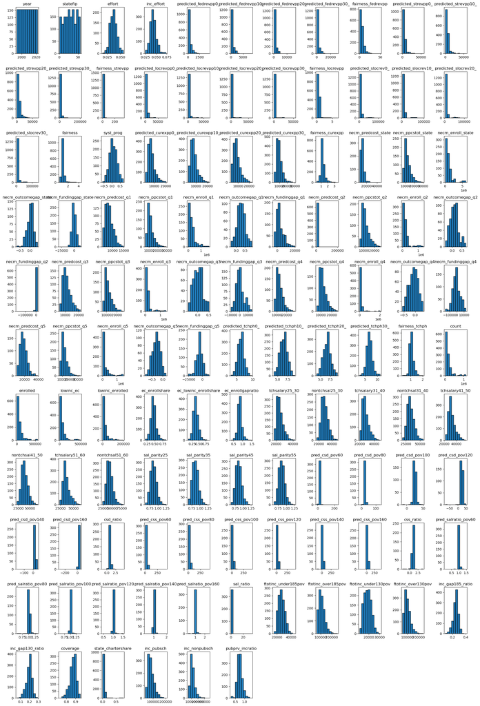

```python
df.hist(figsize=(20,30),grid=False,edgecolor='black')
plt.tight_layout()
plt.show()
```

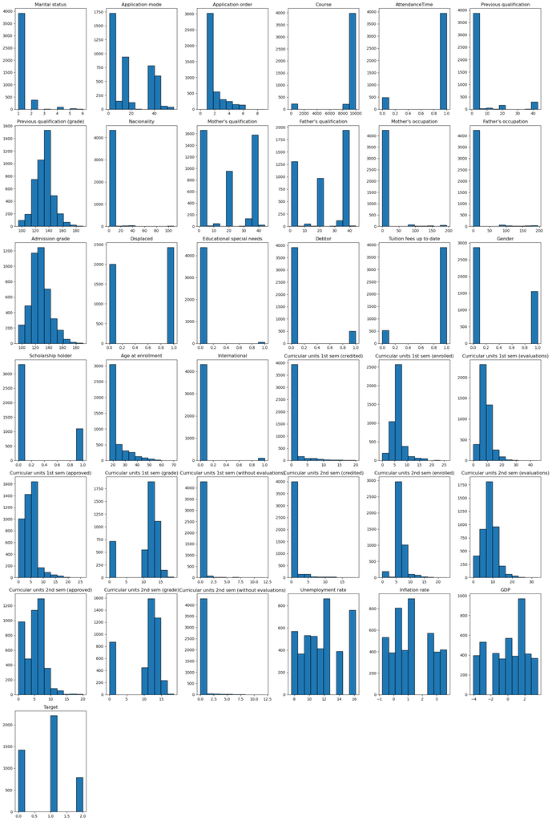

```python
data5.hist(figsize=(20,30),grid=False,edgecolor='black')
plt.tight_layout()
plt.show()
```

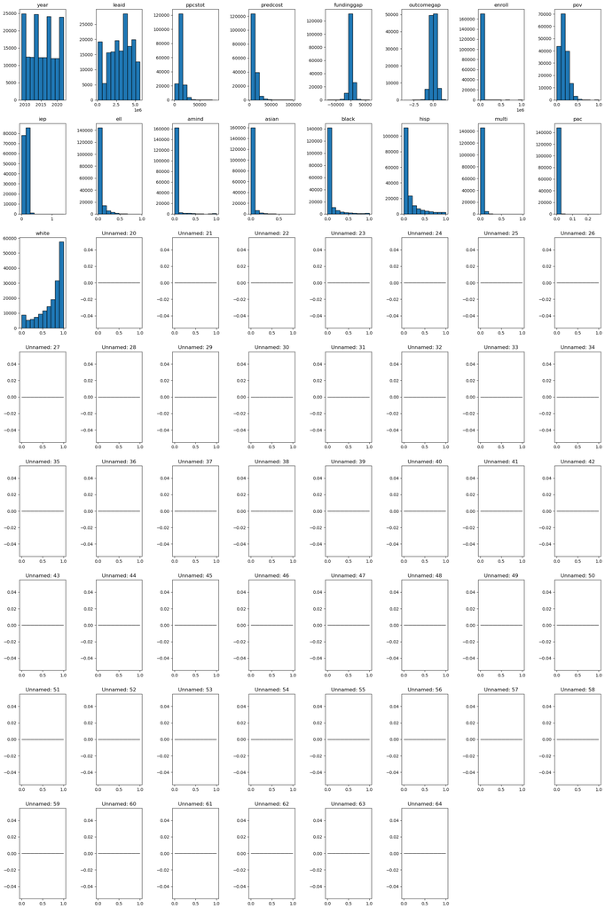

```python
dcd25.hist(figsize=(20,30),grid=False,edgecolor='black')
plt.tight_layout()
plt.show()
```

#### function to find missing values percent in each column

```python
def find_missing(df):
    missing_summary = pd.DataFrame({
    'Column': df.columns,
    'Missing_Count': df.isnull().sum().values,
    'Missing_Percent': (df.isnull().sum() / len(df) * 100).values
    })
    missing_summary = missing_summary.sort_values('Missing_Percent', ascending=False)
    print(missing_summary)

    return missing_summary
```

```python
dfsummary = find_missing(df)
```

```
             Column  Missing_Count  Missing_Percent
121        citation           1475        96.405229
122          ruling           1474        96.339869
123        casetype           1474        96.339869
120            case           1474        96.339869
88   pred_csd_pov60           1194        78.039216
..              ...            ...              ...
1            stabbr              0         0.000000
2        state_name              0         0.000000
3          statefip              0         0.000000
5           region9              0         0.000000
4           region4              0         0.000000

[124 rows x 3 columns]
```

```python
data5summary = find_missing(data5)
```

```
                                            Column  Missing_Count  \
0                                   Marital status              0
1                                 Application mode              0
2                                Application order              0
3                                           Course              0
4                                   AttendanceTime              0
5                           Previous qualification              0
6                   Previous qualification (grade)              0
7                                      Nacionality              0
8                           Mother's qualification              0
9                           Father's qualification              0
10                             Mother's occupation              0
11                             Father's occupation              0
12                                 Admission grade              0
13                                       Displaced              0
```

[output cut: 62 more lines]

```python
dcd25summary = find_missing(dcd25)
```

```
         Column  Missing_Count  Missing_Percent
25  Unnamed: 25         171004            100.0
57  Unnamed: 57         171004            100.0
26  Unnamed: 26         171004            100.0
27  Unnamed: 27         171004            100.0
32  Unnamed: 32         171004            100.0
..          ...            ...              ...
9        enroll              0              0.0
13        amind              0              0.0
16         hisp              0              0.0
3    state_name              0              0.0
2      district              0              0.0

[65 rows x 3 columns]
```

#### check for columns missing a given percentage of values

###### Function to check columns

```python
# Show columns with missing values between lower and upper bounds and include the number of columns

def show_missing_columns(df, lower_bound, upper_bound):
    missing_percent = (df.isnull().sum() / len(df)) * 100
    filtered_missing = missing_percent[(missing_percent > lower_bound) & (missing_percent <= upper_bound)]
    count = len(filtered_missing)

    # Generate markdown table
    table_df = filtered_missing.reset_index()
    table_df.columns = ['Column', 'Missing %']
    table_df['Missing %'] = table_df['Missing %'].round(2)
    print(f"Count: \033[1m{count}\033[0m columns with missing values between {lower_bound}% and {upper_bound}%:")
    print(table_df.to_markdown(index=False))
    print('\n')

    return filtered_missing, count
```

###### Calls to function

```python
df_Percent95, df_percent95_count = show_missing_columns(df, 95, 100)
df_Percent80_95, df_percent80_95_count = show_missing_columns(df, 80, 95)
df_Percent70_80, df_percent70_80_count = show_missing_columns(df, 70, 80)
df_Percent50_70, df_percent50_70_count = show_missing_columns(df, 50, 70)
```

```
Count: 4 columns with missing values between 95% and 100%:
| Column   |   Missing % |
|:---------|------------:|
| case     |       96.34 |
| citation |       96.41 |
| ruling   |       96.34 |
| casetype |       96.34 |


Count: 0 columns with missing values between 80% and 95%:
| Column   | Missing %   |
|----------|-------------|


Count: 21 columns with missing values between 70% and 80%:
| Column               |   Missing % |
|:---------------------|------------:|
| pred_csd_pov60       |       78.04 |
| pred_csd_pov80       |       78.04 |
| pred_csd_pov100      |       78.04 |
| pred_csd_pov120      |       78.04 |
| pred_csd_pov140      |       78.04 |
| pred_csd_pov160      |       78.04 |
| csd_ratio            |       78.04 |
| pred_css_pov60       |       78.04 |
| pred_css_pov80       |       78.04 |
| pred_css_pov100      |       78.04 |
| pred_css_pov120      |       78.04 |
| pred_css_pov140      |       78.04 |
| pred_css_pov160      |       78.04 |
| css_ratio            |       78.04 |
| pred_salratio_pov60  |       76.67 |
| pred_salratio_pov80  |       76.67 |
| pred_salratio_pov100 |       76.67 |
| pred_salratio_pov120 |       76.67 |
| pred_salratio_pov140 |       76.67 |
| pred_salratio_pov160 |       76.67 |
| sal_ratio            |       76.67 |


```

[output cut: 18 more lines]

```
| necm_predcost_q3      |       56.47 |
| necm_ppcstot_q3       |       56.47 |
| necm_enroll_q3        |       56.47 |
| necm_outcomegap_q3    |       66.21 |
| necm_fundinggap_q3    |       56.47 |
| necm_predcost_q4      |       56.47 |
| necm_ppcstot_q4       |       56.47 |
| necm_enroll_q4        |       56.47 |
| necm_outcomegap_q4    |       66.21 |
| necm_fundinggap_q4    |       56.47 |
| necm_predcost_q5      |       55.56 |
| necm_ppcstot_q5       |       55.56 |
| necm_enroll_q5        |       55.56 |
| necm_outcomegap_q5    |       65.49 |
| necm_fundinggap_q5    |       55.56 |
```

```python
data5_Percent95, data5_percent95_count = show_missing_columns(data5, 95, 100)
data5_Percent80_95, data5_percent80_95_count = show_missing_columns(data5, 80, 95)
data5_Percent70_80, data5_percent70_80_count = show_missing_columns(data5, 70, 80)
data5_Percent50_70, data5_percent50_70_count = show_missing_columns(data5, 50, 70)
```

```
Count: 0 columns with missing values between 95% and 100%:
| Column   | Missing %   |
|----------|-------------|


Count: 0 columns with missing values between 80% and 95%:
| Column   | Missing %   |
|----------|-------------|


Count: 0 columns with missing values between 70% and 80%:
| Column   | Missing %   |
|----------|-------------|


Count: 0 columns with missing values between 50% and 70%:
| Column   | Missing %   |
|----------|-------------|
```

```python
dcd25_Percent95, dcd25_percent95_count = show_missing_columns(dcd25, 95, 100)
dcd25_Percent80_95, dcd25_percent80_95_count = show_missing_columns(dcd25, 80, 95)
dcd25_Percent70_80, dcd25_percent70_80_count = show_missing_columns(dcd25, 70, 80)
dcd25_Percent50_70, dcd25_percent50_70_count = show_missing_columns(dcd25, 50, 70)
```

```
Count: 45 columns with missing values between 95% and 100%:
| Column      |   Missing % |
|:------------|------------:|
| Unnamed: 20 |         100 |
| Unnamed: 21 |         100 |
| Unnamed: 22 |         100 |
| Unnamed: 23 |         100 |
| Unnamed: 24 |         100 |
| Unnamed: 25 |         100 |
| Unnamed: 26 |         100 |
| Unnamed: 27 |         100 |
| Unnamed: 28 |         100 |
| Unnamed: 29 |         100 |
| Unnamed: 30 |         100 |
| Unnamed: 31 |         100 |
| Unnamed: 32 |         100 |
| Unnamed: 33 |         100 |
| Unnamed: 34 |         100 |
| Unnamed: 35 |         100 |
| Unnamed: 36 |         100 |
| Unnamed: 37 |         100 |
| Unnamed: 38 |         100 |
| Unnamed: 39 |         100 |
| Unnamed: 40 |         100 |
| Unnamed: 41 |         100 |
| Unnamed: 42 |         100 |
| Unnamed: 43 |         100 |
| Unnamed: 44 |         100 |
| Unnamed: 45 |         100 |
| Unnamed: 46 |         100 |
| Unnamed: 47 |         100 |
| Unnamed: 48 |         100 |
| Unnamed: 49 |         100 |
| Unnamed: 50 |         100 |
| Unnamed: 51 |         100 |
| Unnamed: 52 |         100 |
| Unnamed: 53 |         100 |
| Unnamed: 54 |         100 |
| Unnamed: 55 |         100 |
| Unnamed: 56 |         100 |
```

[output cut: 8 more lines]

```


Count: 0 columns with missing values between 80% and 95%:
| Column   | Missing %   |
|----------|-------------|


Count: 0 columns with missing values between 70% and 80%:
| Column   | Missing %   |
|----------|-------------|


Count: 0 columns with missing values between 50% and 70%:
| Column   | Missing %   |
|----------|-------------|
```

```python
print("Columns with more than 95% missing values:", dcd25_percent95_count, dcd25_Percent95.index.tolist())
print("Columns with 80-95% missing values:", dcd25_percent80_95_count, dcd25_Percent80_95.index.tolist())
print("Columns with 70-80% missing values:", dcd25_percent70_80_count, dcd25_Percent70_80.index.tolist())
print("Columns with 50-70% missing values:", dcd25_percent50_70_count, dcd25_Percent50_70.index.tolist())
```

```
Columns with more than 95% missing values: 45 ['Unnamed: 20', 'Unnamed: 21', 'Unnamed: 22', 'Unnamed: 23', 'Unnamed: 24', 'Unnamed: 25', 'Unnamed: 26', 'Unnamed: 27', 'Unnamed: 28', 'Unnamed: 29', 'Unnamed: 30', 'Unnamed: 31', 'Unnamed: 32', 'Unnamed: 33', 'Unnamed: 34', 'Unnamed: 35', 'Unnamed: 36'…
Columns with 80-95% missing values: 0 []
Columns with 70-80% missing values: 0 []
Columns with 50-70% missing values: 0 []
```

###### Information Printout for missing columns

```python
unneeded_cols = ['stabbr', 'state_name']
replace_cols = ['region4', 'region9']

print(
    "1. Dropping the state abbreviation and the state name is inconsequential since\n"
    "   the state FIPS code uniquely identifies each state.\n"
    f"2. Drop columns that could be replaced: \033[1m\033[4m{unneeded_cols}\033[3m\033[0m\n"
    f"3. Consider replacing region columns with numeric data later:  \033[1m\033[4m{replace_cols}\033[3m\033[0m\n"
    )
print(f"Columns with more than 95% missing values: \033[1m\033[4m{df_percent95_count}\033[3m\033[0m,\n",df_Percent95.index.tolist())
print(f"Columns with 80-95% missing values: \033[1m\033[4m{df_percent80_95_count}\033[3m\033[0m,\n",df_Percent80_95.index.tolist())
print(f"Columns with 70-80% missing values: \033[1m\033[4m{df_percent70_80_count}\033[3m\033[0m,\n",df_Percent70_80.index.tolist())
print(f"Columns with 50-70% missing values: \033[1m\033[4m{df_percent50_70_count}\033[3m\033[0m,\n",df_Percent50_70.index.tolist())
```

```
1. Dropping the state abbreviation and the state name is inconsequential since
   the state FIPS code uniquely identifies each state.
2. Drop columns that could be replaced: ['stabbr', 'state_name']
3. Consider replacing region columns with numeric data later:  ['region4', 'region9']

Columns with more than 95% missing values: 4,
 ['case', 'citation', 'ruling', 'casetype']
Columns with 80-95% missing values: 0,
 []
Columns with 70-80% missing values: 21,
 ['pred_csd_pov60', 'pred_csd_pov80', 'pred_csd_pov100', 'pred_csd_pov120', 'pred_csd_pov140', 'pred_csd_pov160', 'csd_ratio', 'pred_css_pov60', 'pred_css_pov80', 'pred_css_pov100', 'pred_css_pov120', 'pred_css_pov140', 'pred_css_pov160', 'css_ratio', 'pred_salratio_pov60', 'pred_salratio_pov80', 'p…
Columns with 50-70% missing values: 30,
 ['necm_predcost_state', 'necm_ppcstot_state', 'necm_enroll_state', 'necm_outcomegap_state', 'necm_fundinggap_state', 'necm_predcost_q1', 'necm_ppcstot_q1', 'necm_enroll_q1', 'necm_outcomegap_q1', 'necm_fundinggap_q1', 'necm_predcost_q2', 'necm_ppcstot_q2', 'necm_enroll_q2', 'necm_outcomegap_q2', 'n…
```

```python
df_new = df.copy()
```

```python
df_new_dropped = df_new.drop(columns=unneeded_cols)
df_new_dropped.shape # check rows/instances and columns/features after dropping unneeded columns
df_new_dropped
```

|  | year | statefip | region4 | region9 | effort | inc_effort | predicted_fedrevpp0_ | predicted_fedrevpp10_ | predicted_fedrevpp20_ | predicted_fedrevpp30_ | ... | inc_gap130_ratio | coverage | state_chartershare | inc_pubsch | inc_nonpubsch | pubprv_incratio | case | citation | ruling | casetype |
| --- | --- | --- | --- | --- | --- | --- | --- | --- | --- | --- | --- | --- | --- | --- | --- | --- | --- | --- | --- | --- | --- |
| 0 | 2022 | 1 | South | East South Central | 0.036929 | 0.039076 | 1108.6490 | 1668.6920 | 2511.6460 | 3780.4240 | ... | 0.187758 | 0.825960 | 0.004447 | 94260.31 | 130562.7 | 0.721955 | NaN | NaN | NaN | NaN |
| 1 | 2022 | 2 | West | Pacific | 0.043423 | 0.056036 | 1776.7740 | 3541.9490 | 7060.7790 | 14075.4700 | ... | 0.225224 | 0.821983 | 0.064936 | 109327.70 | 109224.8 | 1.000942 | NaN | NaN | NaN | NaN |
| 2 | 2022 | 4 | West | Mountain | 0.024628 | 0.026759 | 1067.8530 | 1859.7250 | 3238.8160 | 5640.5800 | ... | 0.190693 | 0.881690 | 0.351399 | 118109.90 | 137257.1 | 0.860501 | NaN | NaN | NaN | NaN |
| 3 | 2022 | 5 | South | West South Central | 0.038394 | 0.037691 | 1381.2480 | 2004.3170 | 2908.4460 | 4220.4190 | ... | 0.206366 | 0.859202 | 0.097590 | 90338.76 | 102996.4 | 0.877106 | NaN | NaN | NaN | NaN |
| 4 | 2022 | 6 | West | Pacific | 0.030721 | 0.036699 | 1214.3630 | 2042.9630 | 3436.9450 | 5782.0860 | ... | 0.155518 | 0.882351 | 0.153031 | 141409.50 | 225058.4 | 0.628324 | NaN | NaN | NaN | NaN |
| ... | ... | ... | ... | ... | ... | ... | ... | ... | ... | ... | ... | ... | ... | ... | ... | ... | ... | ... | ... | ... | ... |
| 1525 | 1993 | 51 | South | South Atlantic | NaN | NaN | 161.5866 | 247.9940 | 380.6070 | 584.1340 | ... | NaN | NaN | NaN | NaN | NaN | NaN | NaN | NaN | NaN | NaN |
| 1526 | 1993 | 53 | West | Pacific | NaN | NaN | 108.5937 | 220.0093 | 445.7360 | 903.0553 | ... | NaN | NaN | NaN | NaN | NaN | NaN | NaN | NaN | NaN | NaN |
| 1527 | 1993 | 54 | South | South Atlantic | NaN | NaN | 235.6424 | 301.9568 | 386.9335 | 495.8242 | ... | NaN | NaN | NaN | NaN | NaN | NaN | NaN | NaN | NaN | NaN |
| 1528 | 1993 | 55 | Midwest | East North Central | NaN | NaN | 112.1720 | 208.0872 | 386.0168 | 716.0889 | ... | NaN | NaN | NaN | NaN | NaN | NaN | NaN | NaN | NaN | NaN |
| 1529 | 1993 | 56 | West | Mountain | NaN | NaN | 117.6081 | 237.4902 | 479.5721 | 968.4166 | ... | NaN | NaN | NaN | NaN | NaN | NaN | NaN | NaN | NaN | NaN |

1530 rows × 122 columns

#### Drop or replace rows

##### DCD df

```python
dcd25_new = dcd25.drop(columns=dcd25_Percent95.index.tolist())
dcd25_new
```

|  | year | leaid | district | state_name | stabbr | ppcstot | predcost | fundinggap | outcomegap | enroll | pov | iep | ell | amind | asian | black | hisp | multi | pac | white |
| --- | --- | --- | --- | --- | --- | --- | --- | --- | --- | --- | --- | --- | --- | --- | --- | --- | --- | --- | --- | --- |
| 0 | 2022 | 100005 | ALBERTVILLE CITY | Alabama | AL | 10266 | 13358 | -3092 | NaN | 5956 | 0.202613 | NaN | 0.160271 | 0.005037 | 0.004365 | 0.042478 | 0.542814 | 0.026024 | 0.000336 | 0.378946 |
| 1 | 2022 | 100030 | ALEXANDER CITY | Alabama | AL | 12566 | 19503 | -6937 | NaN | 2927 | 0.266441 | NaN | 0.033481 | 0.000000 | 0.010598 | 0.398633 | 0.090940 | 0.040000 | 0.000000 | 0.459829 |
| 2 | 2022 | 100060 | ANDALUSIA CITY | Alabama | AL | 11436 | 17564 | -6128 | NaN | 1862 | 0.257802 | NaN | 0.006982 | 0.003224 | 0.011284 | 0.281569 | 0.029017 | 0.032241 | 0.001612 | 0.641053 |
| 3 | 2022 | 100090 | ANNISTON CITY | Alabama | AL | 13896 | 33488 | -19592 | NaN | 1908 | 0.349931 | NaN | 0.015199 | 0.000000 | 0.000000 | 0.863208 | 0.050839 | 0.028826 | 0.000524 | 0.056604 |
| 4 | 2022 | 100100 | ARAB CITY | Alabama | AL | 10682 | 9721 | 961 | NaN | 2645 | 0.159391 | NaN | 0.009830 | 0.004159 | 0.010208 | 0.007183 | 0.032514 | 0.008318 | 0.001134 | 0.936484 |
| ... | ... | ... | ... | ... | ... | ... | ... | ... | ... | ... | ... | ... | ... | ... | ... | ... | ... | ... | ... | ... |
| 170999 | 2009 | 5604500 | UINTA COUNTY SCHOOL DISTRICT #4 | Wyoming | WY | 14008 | 7066 | 6942 | -0.040183 | 730 | 0.069836 | 0.201370 | 0.000000 | 0.006849 | 0.001370 | 0.002740 | 0.010959 | NaN | NaN | 0.978082 |
| 171000 | 2009 | 5604260 | UINTA COUNTY SCHOOL DISTRICT #6 | Wyoming | WY | 15735 | 7658 | 8077 | -0.035458 | 672 | 0.085271 | 0.211310 | 0.010417 | 0.004464 | 0.007441 | 0.008929 | 0.035714 | NaN | NaN | 0.943452 |
| 171001 | 2009 | 5606240 | WASHAKIE COUNTY SCHOOL DISTRICT #1 | Wyoming | WY | 14987 | 9831 | 5156 | 0.342768 | 1306 | 0.128354 | 0.267228 | 0.058193 | 0.006891 | 0.006891 | 0.001531 | 0.210567 | NaN | NaN | 0.774119 |
| 171002 | 2009 | 5604830 | WESTON COUNTY SCHOOL DISTRICT #1 | Wyoming | WY | 14750 | 8614 | 6136 | 0.005301 | 820 | 0.092428 | 0.258537 | 0.000000 | 0.023171 | 0.006098 | 0.007317 | 0.035366 | NaN | NaN | 0.928049 |
| 171003 | 2009 | 5606090 | WESTON COUNTY SCHOOL DISTRICT #7 | Wyoming | WY | 17859 | 8728 | 9131 | -0.082098 | 291 | 0.070485 | 0.164948 | 0.000000 | 0.017182 | 0.000000 | 0.003436 | 0.024055 | NaN | NaN | 0.955326 |

171004 rows × 20 columns

###### Rerun the histogram EDA for the dcd dataset

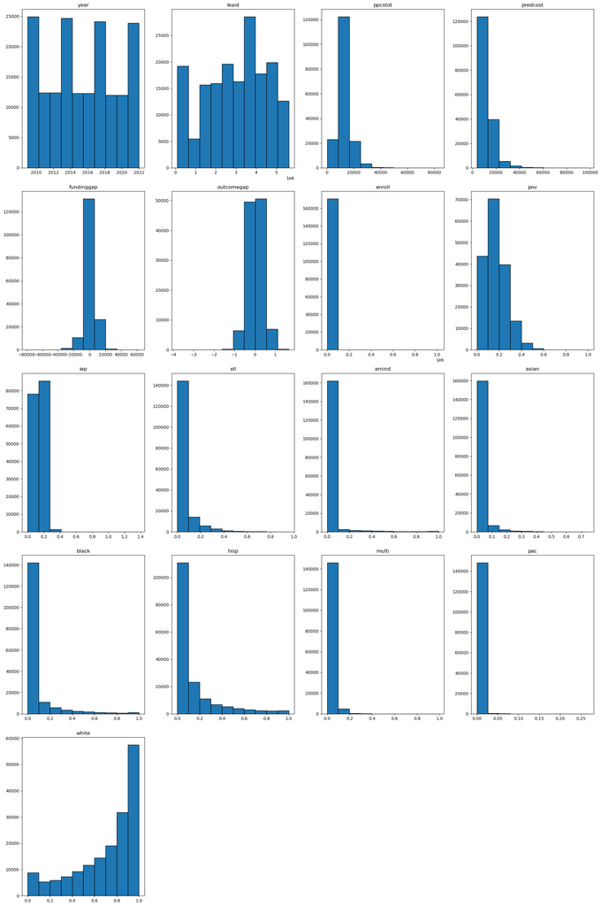

```python
dcd25_new.hist(figsize=(20,30),grid=False,edgecolor='black')
plt.tight_layout()
plt.show()
```

```python
# rename columns in dcd25_new for clarity
dcd25_renamed = dcd25_new.rename(columns={'predcost': 'req_spending', 'ppcstot': 'actual_spending', 'ell': 'per_eng_learn', 'leaid': 'district_id', 'iep': 'per_speced', 'fundinggap': 'req_actual_diff', 'outcomegap': 'testscore_gap', 'amind': 'per_amerindian', 'asian': 'per_asian', 'black': 'per_black', 'hisp': 'per_hispanic', 'white': 'per_white', 'multi': 'per_multi', 'pac': 'per_pac_hi'})
dcd25_renamed
```

|  | year | district_id | district | state_name | stabbr | actual_spending | req_spending | req_actual_diff | testscore_gap | enroll | pov | per_speced | per_eng_learn | per_amerindian | per_asian | per_black | per_hispanic | per_multi | per_pac_hi | per_white |
| --- | --- | --- | --- | --- | --- | --- | --- | --- | --- | --- | --- | --- | --- | --- | --- | --- | --- | --- | --- | --- |
| 0 | 2022 | 100005 | ALBERTVILLE CITY | Alabama | AL | 10266 | 13358 | -3092 | NaN | 5956 | 0.202613 | NaN | 0.160271 | 0.005037 | 0.004365 | 0.042478 | 0.542814 | 0.026024 | 0.000336 | 0.378946 |
| 1 | 2022 | 100030 | ALEXANDER CITY | Alabama | AL | 12566 | 19503 | -6937 | NaN | 2927 | 0.266441 | NaN | 0.033481 | 0.000000 | 0.010598 | 0.398633 | 0.090940 | 0.040000 | 0.000000 | 0.459829 |
| 2 | 2022 | 100060 | ANDALUSIA CITY | Alabama | AL | 11436 | 17564 | -6128 | NaN | 1862 | 0.257802 | NaN | 0.006982 | 0.003224 | 0.011284 | 0.281569 | 0.029017 | 0.032241 | 0.001612 | 0.641053 |
| 3 | 2022 | 100090 | ANNISTON CITY | Alabama | AL | 13896 | 33488 | -19592 | NaN | 1908 | 0.349931 | NaN | 0.015199 | 0.000000 | 0.000000 | 0.863208 | 0.050839 | 0.028826 | 0.000524 | 0.056604 |
| 4 | 2022 | 100100 | ARAB CITY | Alabama | AL | 10682 | 9721 | 961 | NaN | 2645 | 0.159391 | NaN | 0.009830 | 0.004159 | 0.010208 | 0.007183 | 0.032514 | 0.008318 | 0.001134 | 0.936484 |
| ... | ... | ... | ... | ... | ... | ... | ... | ... | ... | ... | ... | ... | ... | ... | ... | ... | ... | ... | ... | ... |
| 170999 | 2009 | 5604500 | UINTA COUNTY SCHOOL DISTRICT #4 | Wyoming | WY | 14008 | 7066 | 6942 | -0.040183 | 730 | 0.069836 | 0.201370 | 0.000000 | 0.006849 | 0.001370 | 0.002740 | 0.010959 | NaN | NaN | 0.978082 |
| 171000 | 2009 | 5604260 | UINTA COUNTY SCHOOL DISTRICT #6 | Wyoming | WY | 15735 | 7658 | 8077 | -0.035458 | 672 | 0.085271 | 0.211310 | 0.010417 | 0.004464 | 0.007441 | 0.008929 | 0.035714 | NaN | NaN | 0.943452 |
| 171001 | 2009 | 5606240 | WASHAKIE COUNTY SCHOOL DISTRICT #1 | Wyoming | WY | 14987 | 9831 | 5156 | 0.342768 | 1306 | 0.128354 | 0.267228 | 0.058193 | 0.006891 | 0.006891 | 0.001531 | 0.210567 | NaN | NaN | 0.774119 |
| 171002 | 2009 | 5604830 | WESTON COUNTY SCHOOL DISTRICT #1 | Wyoming | WY | 14750 | 8614 | 6136 | 0.005301 | 820 | 0.092428 | 0.258537 | 0.000000 | 0.023171 | 0.006098 | 0.007317 | 0.035366 | NaN | NaN | 0.928049 |
| 171003 | 2009 | 5606090 | WESTON COUNTY SCHOOL DISTRICT #7 | Wyoming | WY | 17859 | 8728 | 9131 | -0.082098 | 291 | 0.070485 | 0.164948 | 0.000000 | 0.017182 | 0.000000 | 0.003436 | 0.024055 | NaN | NaN | 0.955326 |

171004 rows × 20 columns

##### df dataframe

```python
df_new = df.copy()
df_new.shape # check rows/instances and columns/features
```

```
(1530, 124)
```

###### Drop columns with data that can be inferred from other columns

```python
unneeded_cols = ['stabbr', 'state_name']

df_new_dropped = df_new.drop(columns=unneeded_cols)
df_new_dropped.shape # check rows/instances and columns/features after dropping unneeded columns
df_new_dropped
```

|  | year | statefip | region4 | region9 | effort | inc_effort | predicted_fedrevpp0_ | predicted_fedrevpp10_ | predicted_fedrevpp20_ | predicted_fedrevpp30_ | ... | inc_gap130_ratio | coverage | state_chartershare | inc_pubsch | inc_nonpubsch | pubprv_incratio | case | citation | ruling | casetype |
| --- | --- | --- | --- | --- | --- | --- | --- | --- | --- | --- | --- | --- | --- | --- | --- | --- | --- | --- | --- | --- | --- |
| 0 | 2022 | 1 | South | East South Central | 0.036929 | 0.039076 | 1108.6490 | 1668.6920 | 2511.6460 | 3780.4240 | ... | 0.187758 | 0.825960 | 0.004447 | 94260.31 | 130562.7 | 0.721955 | NaN | NaN | NaN | NaN |
| 1 | 2022 | 2 | West | Pacific | 0.043423 | 0.056036 | 1776.7740 | 3541.9490 | 7060.7790 | 14075.4700 | ... | 0.225224 | 0.821983 | 0.064936 | 109327.70 | 109224.8 | 1.000942 | NaN | NaN | NaN | NaN |
| 2 | 2022 | 4 | West | Mountain | 0.024628 | 0.026759 | 1067.8530 | 1859.7250 | 3238.8160 | 5640.5800 | ... | 0.190693 | 0.881690 | 0.351399 | 118109.90 | 137257.1 | 0.860501 | NaN | NaN | NaN | NaN |
| 3 | 2022 | 5 | South | West South Central | 0.038394 | 0.037691 | 1381.2480 | 2004.3170 | 2908.4460 | 4220.4190 | ... | 0.206366 | 0.859202 | 0.097590 | 90338.76 | 102996.4 | 0.877106 | NaN | NaN | NaN | NaN |
| 4 | 2022 | 6 | West | Pacific | 0.030721 | 0.036699 | 1214.3630 | 2042.9630 | 3436.9450 | 5782.0860 | ... | 0.155518 | 0.882351 | 0.153031 | 141409.50 | 225058.4 | 0.628324 | NaN | NaN | NaN | NaN |
| ... | ... | ... | ... | ... | ... | ... | ... | ... | ... | ... | ... | ... | ... | ... | ... | ... | ... | ... | ... | ... | ... |
| 1525 | 1993 | 51 | South | South Atlantic | NaN | NaN | 161.5866 | 247.9940 | 380.6070 | 584.1340 | ... | NaN | NaN | NaN | NaN | NaN | NaN | NaN | NaN | NaN | NaN |
| 1526 | 1993 | 53 | West | Pacific | NaN | NaN | 108.5937 | 220.0093 | 445.7360 | 903.0553 | ... | NaN | NaN | NaN | NaN | NaN | NaN | NaN | NaN | NaN | NaN |
| 1527 | 1993 | 54 | South | South Atlantic | NaN | NaN | 235.6424 | 301.9568 | 386.9335 | 495.8242 | ... | NaN | NaN | NaN | NaN | NaN | NaN | NaN | NaN | NaN | NaN |
| 1528 | 1993 | 55 | Midwest | East North Central | NaN | NaN | 112.1720 | 208.0872 | 386.0168 | 716.0889 | ... | NaN | NaN | NaN | NaN | NaN | NaN | NaN | NaN | NaN | NaN |
| 1529 | 1993 | 56 | West | Mountain | NaN | NaN | 117.6081 | 237.4902 | 479.5721 | 968.4166 | ... | NaN | NaN | NaN | NaN | NaN | NaN | NaN | NaN | NaN | NaN |

1530 rows × 122 columns

###### drop cells with more than 95% missing values

```python
# Columns to drop based on missing % from earlier function output
columns_to_drop = df_Percent95.index.tolist()

data_with_drops95 = df_new_dropped.drop(columns_to_drop, axis=1)
data_with_drops95
```

|  | year | statefip | region4 | region9 | effort | inc_effort | predicted_fedrevpp0_ | predicted_fedrevpp10_ | predicted_fedrevpp20_ | predicted_fedrevpp30_ | ... | ftotinc_over185pov | ftotinc_under130pov | ftotinc_over130pov | inc_gap185_ratio | inc_gap130_ratio | coverage | state_chartershare | inc_pubsch | inc_nonpubsch | pubprv_incratio |
| --- | --- | --- | --- | --- | --- | --- | --- | --- | --- | --- | --- | --- | --- | --- | --- | --- | --- | --- | --- | --- | --- |
| 0 | 2022 | 1 | South | East South Central | 0.036929 | 0.039076 | 1108.6490 | 1668.6920 | 2511.6460 | 3780.4240 | ... | 131652.5 | 22033.44 | 117350.2 | 0.238166 | 0.187758 | 0.825960 | 0.004447 | 94260.31 | 130562.7 | 0.721955 |
| 1 | 2022 | 2 | West | Pacific | 0.043423 | 0.056036 | 1776.7740 | 3541.9490 | 7060.7790 | 14075.4700 | ... | 144930.5 | 29949.38 | 132975.8 | 0.256784 | 0.225224 | 0.821983 | 0.064936 | 109327.70 | 109224.8 | 1.000942 |
| 2 | 2022 | 4 | West | Mountain | 0.024628 | 0.026759 | 1067.8530 | 1859.7250 | 3238.8160 | 5640.5800 | ... | 155276.1 | 26629.32 | 139645.2 | 0.240733 | 0.190693 | 0.881690 | 0.351399 | 118109.90 | 137257.1 | 0.860501 |
| 3 | 2022 | 5 | South | West South Central | 0.038394 | 0.037691 | 1381.2480 | 2004.3170 | 2908.4460 | 4220.4190 | ... | 127862.6 | 23495.69 | 113854.2 | 0.256578 | 0.206366 | 0.859202 | 0.097590 | 90338.76 | 102996.4 | 0.877106 |
| 4 | 2022 | 6 | West | Pacific | 0.030721 | 0.036699 | 1214.3630 | 2042.9630 | 3436.9450 | 5782.0860 | ... | 184344.8 | 25918.38 | 166658.3 | 0.197430 | 0.155518 | 0.882351 | 0.153031 | 141409.50 | 225058.4 | 0.628324 |
| ... | ... | ... | ... | ... | ... | ... | ... | ... | ... | ... | ... | ... | ... | ... | ... | ... | ... | ... | ... | ... | ... |
| 1525 | 1993 | 51 | South | South Atlantic | NaN | NaN | 161.5866 | 247.9940 | 380.6070 | 584.1340 | ... | NaN | NaN | NaN | NaN | NaN | NaN | NaN | NaN | NaN | NaN |
| 1526 | 1993 | 53 | West | Pacific | NaN | NaN | 108.5937 | 220.0093 | 445.7360 | 903.0553 | ... | NaN | NaN | NaN | NaN | NaN | NaN | NaN | NaN | NaN | NaN |
| 1527 | 1993 | 54 | South | South Atlantic | NaN | NaN | 235.6424 | 301.9568 | 386.9335 | 495.8242 | ... | NaN | NaN | NaN | NaN | NaN | NaN | NaN | NaN | NaN | NaN |
| 1528 | 1993 | 55 | Midwest | East North Central | NaN | NaN | 112.1720 | 208.0872 | 386.0168 | 716.0889 | ... | NaN | NaN | NaN | NaN | NaN | NaN | NaN | NaN | NaN | NaN |
| 1529 | 1993 | 56 | West | Mountain | NaN | NaN | 117.6081 | 237.4902 | 479.5721 | 968.4166 | ... | NaN | NaN | NaN | NaN | NaN | NaN | NaN | NaN | NaN | NaN |

1530 rows × 118 columns

```python
# find region9 values
data_with_drops95.groupby(['region9']).size()
```

```
region9
East North Central    150
East South Central    120
Middle Atlantic        90
Mountain              240
New England           180
Pacific               150
South Atlantic        270
West North Central    210
West South Central    120
dtype: int64
```

```python
# find region4 values
data_with_drops95.groupby('region4').size()
```

```
region4
Midwest      360
Northeast    270
South        510
West         390
dtype: int64
```

```python
# ######################################################################################
# #####     NOTE: Running this cell by itself more than once will result in the    #####
# #####     region4 and region9 columns being replaced multiple times,             #####
# #####     ending with missing values                                             #####
# ######################################################################################
# put code for replacing region4 and region9 here
# step 1 - make a copy of the dataframe after dropping unneeded columns
df_copy_after_95drops = data_with_drops95.copy()
# step 2 - replace region4 and region9 with numerical values
region4_mapping = {
    'Northeast': 1,
    'Midwest': 2,
    'South': 3,
    'West': 4
}
df_copy_after_95drops['region4'] = df_copy_after_95drops['region4'].map(region4_mapping)
region9_mapping = {
    'East North Central': 1,
    'East South Central': 2,
    'Middle Atlantic': 3,
    'Mountain': 4,
    'New England': 5,
    'Pacific': 6,
    'South Atlantic': 7,
    'West South Central': 8,
    'West North Central': 9,
}
df_copy_after_95drops['region9'] = df_copy_after_95drops['region9'].map(region9_mapping)
# copy the changed dataframe back to data_with_drops95
data_with_drops95 = df_copy_after_95drops
# copy changed dataframe back to new
df_new = data_with_drops95
# check new dataframe
df_new
```

|  | year | statefip | region4 | region9 | effort | inc_effort | predicted_fedrevpp0_ | predicted_fedrevpp10_ | predicted_fedrevpp20_ | predicted_fedrevpp30_ | ... | ftotinc_over185pov | ftotinc_under130pov | ftotinc_over130pov | inc_gap185_ratio | inc_gap130_ratio | coverage | state_chartershare | inc_pubsch | inc_nonpubsch | pubprv_incratio |
| --- | --- | --- | --- | --- | --- | --- | --- | --- | --- | --- | --- | --- | --- | --- | --- | --- | --- | --- | --- | --- | --- |
| 0 | 2022 | 1 | 3 | 2 | 0.036929 | 0.039076 | 1108.6490 | 1668.6920 | 2511.6460 | 3780.4240 | ... | 131652.5 | 22033.44 | 117350.2 | 0.238166 | 0.187758 | 0.825960 | 0.004447 | 94260.31 | 130562.7 | 0.721955 |
| 1 | 2022 | 2 | 4 | 6 | 0.043423 | 0.056036 | 1776.7740 | 3541.9490 | 7060.7790 | 14075.4700 | ... | 144930.5 | 29949.38 | 132975.8 | 0.256784 | 0.225224 | 0.821983 | 0.064936 | 109327.70 | 109224.8 | 1.000942 |
| 2 | 2022 | 4 | 4 | 4 | 0.024628 | 0.026759 | 1067.8530 | 1859.7250 | 3238.8160 | 5640.5800 | ... | 155276.1 | 26629.32 | 139645.2 | 0.240733 | 0.190693 | 0.881690 | 0.351399 | 118109.90 | 137257.1 | 0.860501 |
| 3 | 2022 | 5 | 3 | 8 | 0.038394 | 0.037691 | 1381.2480 | 2004.3170 | 2908.4460 | 4220.4190 | ... | 127862.6 | 23495.69 | 113854.2 | 0.256578 | 0.206366 | 0.859202 | 0.097590 | 90338.76 | 102996.4 | 0.877106 |
| 4 | 2022 | 6 | 4 | 6 | 0.030721 | 0.036699 | 1214.3630 | 2042.9630 | 3436.9450 | 5782.0860 | ... | 184344.8 | 25918.38 | 166658.3 | 0.197430 | 0.155518 | 0.882351 | 0.153031 | 141409.50 | 225058.4 | 0.628324 |
| ... | ... | ... | ... | ... | ... | ... | ... | ... | ... | ... | ... | ... | ... | ... | ... | ... | ... | ... | ... | ... | ... |
| 1525 | 1993 | 51 | 3 | 7 | NaN | NaN | 161.5866 | 247.9940 | 380.6070 | 584.1340 | ... | NaN | NaN | NaN | NaN | NaN | NaN | NaN | NaN | NaN | NaN |
| 1526 | 1993 | 53 | 4 | 6 | NaN | NaN | 108.5937 | 220.0093 | 445.7360 | 903.0553 | ... | NaN | NaN | NaN | NaN | NaN | NaN | NaN | NaN | NaN | NaN |
| 1527 | 1993 | 54 | 3 | 7 | NaN | NaN | 235.6424 | 301.9568 | 386.9335 | 495.8242 | ... | NaN | NaN | NaN | NaN | NaN | NaN | NaN | NaN | NaN | NaN |
| 1528 | 1993 | 55 | 2 | 1 | NaN | NaN | 112.1720 | 208.0872 | 386.0168 | 716.0889 | ... | NaN | NaN | NaN | NaN | NaN | NaN | NaN | NaN | NaN | NaN |
| 1529 | 1993 | 56 | 4 | 4 | NaN | NaN | 117.6081 | 237.4902 | 479.5721 | 968.4166 | ... | NaN | NaN | NaN | NaN | NaN | NaN | NaN | NaN | NaN | NaN |

1530 rows × 118 columns

###### drop cells which have between 80 and 95 percent missing values

```python
columns_to_drop = df_Percent80_95.index.tolist()

data_with_drops80_95 = data_with_drops95.drop(columns_to_drop, axis=1)
data_with_drops80_95.shape # check rows/instances and columns/features
```

```
(1530, 118)
```

###### drop cells which have between 70 and 80 percent missing values

```python
columns_to_drop = df_Percent70_80.index.tolist()
data_with_drops70_80 = data_with_drops80_95.drop(columns_to_drop, axis=1)
data_with_drops70_80.shape # check rows/instances and columns/features
```

```
(1530, 97)
```

###### drop cells which have between 50 and 70 percent missing values

```python
columns_to_drop = df_Percent50_70.index.tolist()
data_with_drops50_70 = data_with_drops70_80.drop(columns_to_drop, axis=1)
data_with_drops50_70.shape # check rows/instances and columns/features
```

```
(1530, 67)
```

##### df dataframe

###### fill missing values with mode when feature is numeric

```python
# Fill missing values in numeric columns with their mode
dfnew = data_with_drops95.copy()
numeric_cols = dfnew.select_dtypes(include=['int64', 'float64']).columns
dfnew[numeric_cols] = dfnew[numeric_cols].fillna(dfnew[numeric_cols].mode().iloc[0])

# Verify the changes
print("Missing values after filling with mode:")
print(dfnew.isnull().sum())
```

```
Missing values after filling with mode:
year                  0
statefip              0
region4               0
region9               0
effort                0
                     ..
coverage              0
state_chartershare    0
inc_pubsch            0
inc_nonpubsch         0
pubprv_incratio       0
Length: 118, dtype: int64
```

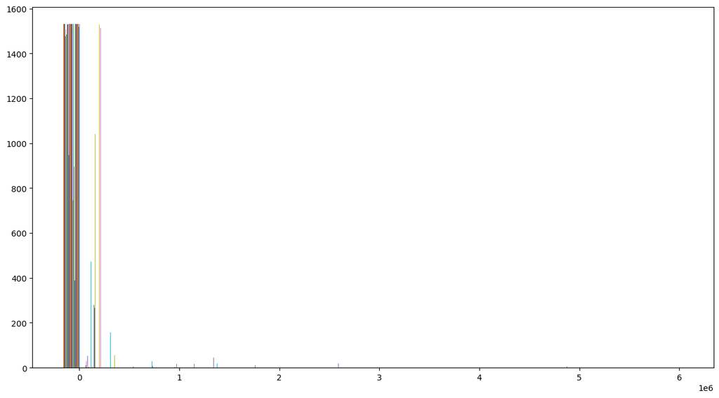

```python
figsize = (15, 8)
plt.figure(figsize=figsize)

_ = plt.hist(dfnew[numeric_cols], bins=30)
```

```python
test = df[numeric_cols].isna().sum(axis=0)
test
```

```
year                    0
statefip                0
region4                 0
region9                 0
effort                668
                     ...
coverage              357
state_chartershare    408
inc_pubsch            357
inc_nonpubsch         357
pubprv_incratio       357
Length: 118, dtype: int64
```

```python
df.groupby(['inc_pubsch']).size()
```

```
inc_pubsch
39960.21     1
41628.00     1
41847.97     1
42162.23     1
42371.82     1
            ..
177988.70    1
178049.10    1
181087.50    1
185075.50    1
202162.30    1
Length: 1173, dtype: int64
```

```python
df.groupby(['inc_effort']).size()
```

```
inc_effort
0.025232    1
0.025314    1
0.025563    1
0.026198    1
0.026759    1
           ..
0.071275    1
0.071514    1
0.072645    1
0.073249    1
0.073341    1
Length: 1218, dtype: int64
```

###### fill missing values in categorical columns

```python
# Fill missing values in categorical (object) columns with 'NONE'
cat_cols = data_with_drops95.select_dtypes(include=['object', 'category']).columns
data_with_drops95[cat_cols] = data_with_drops95[cat_cols].fillna('NONE')

# Verify the changes
print("Missing values after filling categorical columns with 'NONE':")
print(data_with_drops95[cat_cols].isnull().sum())
data_with_drops95 # check rows/instances and columns/features
```

```
Missing values after filling categorical columns with 'NONE':
Series([], dtype: float64)
```

|  | year | statefip | region4 | region9 | effort | inc_effort | predicted_fedrevpp0_ | predicted_fedrevpp10_ | predicted_fedrevpp20_ | predicted_fedrevpp30_ | ... | ftotinc_over185pov | ftotinc_under130pov | ftotinc_over130pov | inc_gap185_ratio | inc_gap130_ratio | coverage | state_chartershare | inc_pubsch | inc_nonpubsch | pubprv_incratio |
| --- | --- | --- | --- | --- | --- | --- | --- | --- | --- | --- | --- | --- | --- | --- | --- | --- | --- | --- | --- | --- | --- |
| 0 | 2022 | 1 | 3 | 2 | 0.036929 | 0.039076 | 1108.6490 | 1668.6920 | 2511.6460 | 3780.4240 | ... | 131652.5 | 22033.44 | 117350.2 | 0.238166 | 0.187758 | 0.825960 | 0.004447 | 94260.31 | 130562.7 | 0.721955 |
| 1 | 2022 | 2 | 4 | 6 | 0.043423 | 0.056036 | 1776.7740 | 3541.9490 | 7060.7790 | 14075.4700 | ... | 144930.5 | 29949.38 | 132975.8 | 0.256784 | 0.225224 | 0.821983 | 0.064936 | 109327.70 | 109224.8 | 1.000942 |
| 2 | 2022 | 4 | 4 | 4 | 0.024628 | 0.026759 | 1067.8530 | 1859.7250 | 3238.8160 | 5640.5800 | ... | 155276.1 | 26629.32 | 139645.2 | 0.240733 | 0.190693 | 0.881690 | 0.351399 | 118109.90 | 137257.1 | 0.860501 |
| 3 | 2022 | 5 | 3 | 8 | 0.038394 | 0.037691 | 1381.2480 | 2004.3170 | 2908.4460 | 4220.4190 | ... | 127862.6 | 23495.69 | 113854.2 | 0.256578 | 0.206366 | 0.859202 | 0.097590 | 90338.76 | 102996.4 | 0.877106 |
| 4 | 2022 | 6 | 4 | 6 | 0.030721 | 0.036699 | 1214.3630 | 2042.9630 | 3436.9450 | 5782.0860 | ... | 184344.8 | 25918.38 | 166658.3 | 0.197430 | 0.155518 | 0.882351 | 0.153031 | 141409.50 | 225058.4 | 0.628324 |
| ... | ... | ... | ... | ... | ... | ... | ... | ... | ... | ... | ... | ... | ... | ... | ... | ... | ... | ... | ... | ... | ... |
| 1525 | 1993 | 51 | 3 | 7 | NaN | NaN | 161.5866 | 247.9940 | 380.6070 | 584.1340 | ... | NaN | NaN | NaN | NaN | NaN | NaN | NaN | NaN | NaN | NaN |
| 1526 | 1993 | 53 | 4 | 6 | NaN | NaN | 108.5937 | 220.0093 | 445.7360 | 903.0553 | ... | NaN | NaN | NaN | NaN | NaN | NaN | NaN | NaN | NaN | NaN |
| 1527 | 1993 | 54 | 3 | 7 | NaN | NaN | 235.6424 | 301.9568 | 386.9335 | 495.8242 | ... | NaN | NaN | NaN | NaN | NaN | NaN | NaN | NaN | NaN | NaN |
| 1528 | 1993 | 55 | 2 | 1 | NaN | NaN | 112.1720 | 208.0872 | 386.0168 | 716.0889 | ... | NaN | NaN | NaN | NaN | NaN | NaN | NaN | NaN | NaN | NaN |
| 1529 | 1993 | 56 | 4 | 4 | NaN | NaN | 117.6081 | 237.4902 | 479.5721 | 968.4166 | ... | NaN | NaN | NaN | NaN | NaN | NaN | NaN | NaN | NaN | NaN |

1530 rows × 118 columns

##### df dataframe

###### Create Correlation matrices of numeric columns using a copy of the dataframe

```python
numeric_columns = data_with_drops95.select_dtypes(include=['int64', 'float64']).columns.tolist()
mydf_numeric = data_with_drops95[numeric_columns]

correlation_matrix = mydf_numeric.corr()
print("Correlation Matrix of Numeric Values:")
print(correlation_matrix)

# Visualize the correlation matrix using matplotlib
plt.figure(figsize=(90, 70))
cmap = plt.cm.RdBu_r

# Plot the heatmap
im = plt.imshow(correlation_matrix, cmap=cmap, vmin=-1, vmax=1)
plt.colorbar(im)

plt.title('State Indicators Dataset Correlation Matrix', fontsize=14)
plt.xticks(np.arange(len(numeric_columns)), numeric_columns, rotation=45, ha='right')
plt.yticks(np.arange(len(numeric_columns)), numeric_columns)

# set and print the plot
plt.tight_layout()
plt.show()
```

```
Correlation Matrix of Numeric Values:
                            year      statefip       region4       region9  \
year                1.000000e+00 -2.202760e-15  7.525779e-16 -2.858266e-16
statefip           -2.202760e-15  1.000000e+00 -1.412917e-01 -2.066021e-02
region4             7.525779e-16 -1.412917e-01  1.000000e+00  5.015257e-02
region9            -2.858266e-16 -2.066021e-02  5.015257e-02  1.000000e+00
effort             -2.317874e-01  2.189699e-01 -3.185247e-01 -1.724570e-01
...                          ...           ...           ...           ...
coverage           -1.817435e-01  1.636566e-01  2.072170e-01  2.995301e-02
state_chartershare  2.667191e-01 -2.694502e-01  1.643415e-01  8.783924e-03
inc_pubsch          7.008892e-01 -2.172377e-02 -2.305082e-01 -2.133117e-02
inc_nonpubsch       5.216162e-01 -1.848817e-01 -1.286535e-01  6.108552e-02
pubprv_incratio     1.775317e-01  2.291081e-01 -9.088434e-02 -9.911021e-02

                      effort  inc_effort  predicted_fedrevpp0_  \
year               -0.231787   -0.312681              0.328094
statefip            0.218970    0.121723             -0.118800
region4            -0.318525   -0.114934              0.141293
region9            -0.172457   -0.059829              0.070589
effort              1.000000    0.669339             -0.046854
...                      ...         ...                   ...
coverage            0.192847    0.117799             -0.217369
state_chartershare -0.481307   -0.022313              0.198996
inc_pubsch         -0.209796   -0.247127              0.308518
inc_nonpubsch      -0.407246   -0.205707              0.289310
pubprv_incratio     0.264839    0.075417              0.008535

                    predicted_fedrevpp10_  predicted_fedrevpp20_  \
year                             0.346304               0.333996
statefip                        -0.126921              -0.123102
region4                          0.116527               0.086334
region9                          0.078451               0.082648
effort                          -0.031676              -0.009701
...                                   ...                    ...
coverage                        -0.208831              -0.150329
state_chartershare               0.181142               0.119901
inc_pubsch                       0.422746               0.459859
inc_nonpubsch                    0.286824               0.214908
pubprv_incratio                  0.212014               0.408251

```

[output cut: 38 more lines]

```

                    inc_pubsch  inc_nonpubsch  pubprv_incratio
year                  0.700889       0.521616         0.177532
statefip             -0.021724      -0.184882         0.229108
region4              -0.230508      -0.128654        -0.090884
region9              -0.021331       0.061086        -0.099110
effort               -0.209796      -0.407246         0.264839
...                        ...            ...              ...
coverage             -0.192836      -0.300565         0.195017
state_chartershare    0.286211       0.550551        -0.239642
inc_pubsch            1.000000       0.776533         0.225904
inc_nonpubsch         0.776533       1.000000        -0.383200
pubprv_incratio       0.225904      -0.383200         1.000000

[118 rows x 118 columns]
```

[figure not shown]

###### Remove duplicates if they exist

```python
maskdup = data_with_drops95.duplicated()
df_new_nodupe = data_with_drops95[~maskdup]
df_new_nodupe
```

|  | year | statefip | region4 | region9 | effort | inc_effort | predicted_fedrevpp0_ | predicted_fedrevpp10_ | predicted_fedrevpp20_ | predicted_fedrevpp30_ | ... | ftotinc_over185pov | ftotinc_under130pov | ftotinc_over130pov | inc_gap185_ratio | inc_gap130_ratio | coverage | state_chartershare | inc_pubsch | inc_nonpubsch | pubprv_incratio |
| --- | --- | --- | --- | --- | --- | --- | --- | --- | --- | --- | --- | --- | --- | --- | --- | --- | --- | --- | --- | --- | --- |
| 0 | 2022 | 1 | 3 | 2 | 0.036929 | 0.039076 | 1108.6490 | 1668.6920 | 2511.6460 | 3780.4240 | ... | 131652.5 | 22033.44 | 117350.2 | 0.238166 | 0.187758 | 0.825960 | 0.004447 | 94260.31 | 130562.7 | 0.721955 |
| 1 | 2022 | 2 | 4 | 6 | 0.043423 | 0.056036 | 1776.7740 | 3541.9490 | 7060.7790 | 14075.4700 | ... | 144930.5 | 29949.38 | 132975.8 | 0.256784 | 0.225224 | 0.821983 | 0.064936 | 109327.70 | 109224.8 | 1.000942 |
| 2 | 2022 | 4 | 4 | 4 | 0.024628 | 0.026759 | 1067.8530 | 1859.7250 | 3238.8160 | 5640.5800 | ... | 155276.1 | 26629.32 | 139645.2 | 0.240733 | 0.190693 | 0.881690 | 0.351399 | 118109.90 | 137257.1 | 0.860501 |
| 3 | 2022 | 5 | 3 | 8 | 0.038394 | 0.037691 | 1381.2480 | 2004.3170 | 2908.4460 | 4220.4190 | ... | 127862.6 | 23495.69 | 113854.2 | 0.256578 | 0.206366 | 0.859202 | 0.097590 | 90338.76 | 102996.4 | 0.877106 |
| 4 | 2022 | 6 | 4 | 6 | 0.030721 | 0.036699 | 1214.3630 | 2042.9630 | 3436.9450 | 5782.0860 | ... | 184344.8 | 25918.38 | 166658.3 | 0.197430 | 0.155518 | 0.882351 | 0.153031 | 141409.50 | 225058.4 | 0.628324 |
| ... | ... | ... | ... | ... | ... | ... | ... | ... | ... | ... | ... | ... | ... | ... | ... | ... | ... | ... | ... | ... | ... |
| 1525 | 1993 | 51 | 3 | 7 | NaN | NaN | 161.5866 | 247.9940 | 380.6070 | 584.1340 | ... | NaN | NaN | NaN | NaN | NaN | NaN | NaN | NaN | NaN | NaN |
| 1526 | 1993 | 53 | 4 | 6 | NaN | NaN | 108.5937 | 220.0093 | 445.7360 | 903.0553 | ... | NaN | NaN | NaN | NaN | NaN | NaN | NaN | NaN | NaN | NaN |
| 1527 | 1993 | 54 | 3 | 7 | NaN | NaN | 235.6424 | 301.9568 | 386.9335 | 495.8242 | ... | NaN | NaN | NaN | NaN | NaN | NaN | NaN | NaN | NaN | NaN |
| 1528 | 1993 | 55 | 2 | 1 | NaN | NaN | 112.1720 | 208.0872 | 386.0168 | 716.0889 | ... | NaN | NaN | NaN | NaN | NaN | NaN | NaN | NaN | NaN | NaN |
| 1529 | 1993 | 56 | 4 | 4 | NaN | NaN | 117.6081 | 237.4902 | 479.5721 | 968.4166 | ... | NaN | NaN | NaN | NaN | NaN | NaN | NaN | NaN | NaN | NaN |

1530 rows × 118 columns

###### get mean, median, and mode of Numeric Columns

```python
mean = mydf_numeric.mean()
median = mydf_numeric.median()
mode = mydf_numeric.mode()

print("Mean:\n", mean, "\n")
print("Median:\n", median, "\n")
print("Mode:\n", mode, "\n")
```

```
Mean:
 year                    2007.500000
statefip                  28.960784
region4                    2.666667
region9                    5.333333
effort                     0.036511
                          ...
coverage                   0.870169
state_chartershare         0.043592
inc_pubsch             84184.277587
inc_nonpubsch         117335.307451
pubprv_incratio            0.734698
Length: 118, dtype: float64

Median:
 year                    2007.500000
statefip                  29.000000
region4                    3.000000
region9                    5.000000
effort                     0.036168
                          ...
coverage                   0.875658
state_chartershare         0.020631
inc_pubsch             79034.990000
inc_nonpubsch         110297.500000
pubprv_incratio            0.721956
Length: 118, dtype: float64

Mode:
         year  statefip  region4  region9    effort  inc_effort  \
0     1993.0       1.0      3.0      7.0  0.015759     0.04804
1     1994.0       2.0      NaN      NaN  0.016090         NaN
2     1995.0       4.0      NaN      NaN  0.019830         NaN
3     1996.0       5.0      NaN      NaN  0.020075         NaN
4     1997.0       6.0      NaN      NaN  0.020496         NaN
...      ...       ...      ...      ...       ...         ...
1465     NaN       NaN      NaN      NaN       NaN         NaN
1466     NaN       NaN      NaN      NaN       NaN         NaN
1467     NaN       NaN      NaN      NaN       NaN         NaN
1468     NaN       NaN      NaN      NaN       NaN         NaN
```

[output cut: 40 more lines]

```

      state_chartershare  inc_pubsch  inc_nonpubsch  pubprv_incratio
0                    0.0    39960.21       48956.75         0.252707
1                    NaN    41628.00       49867.22         0.258640
2                    NaN    41847.97       50145.84         0.314576
3                    NaN    42162.23       50863.59         0.324283
4                    NaN    42371.82       51010.63         0.324484
...                  ...         ...            ...              ...
1465                 NaN         NaN            NaN              NaN
1466                 NaN         NaN            NaN              NaN
1467                 NaN         NaN            NaN              NaN
1468                 NaN         NaN            NaN              NaN
1469                 NaN         NaN            NaN              NaN

[1470 rows x 118 columns]
```

##### DCD 2025 dataframe

###### DCD Correlation matrix annotated

```python
# Create correlation matrix for dcd25_renamed
dcd25_numeric_columns = dcd25_renamed.select_dtypes(include=['int64', 'float64']).columns.tolist()
dcd25_numeric_data = dcd25_renamed[dcd25_numeric_columns]
dcd25_correlation_matrix = dcd25_numeric_data.corr()
```

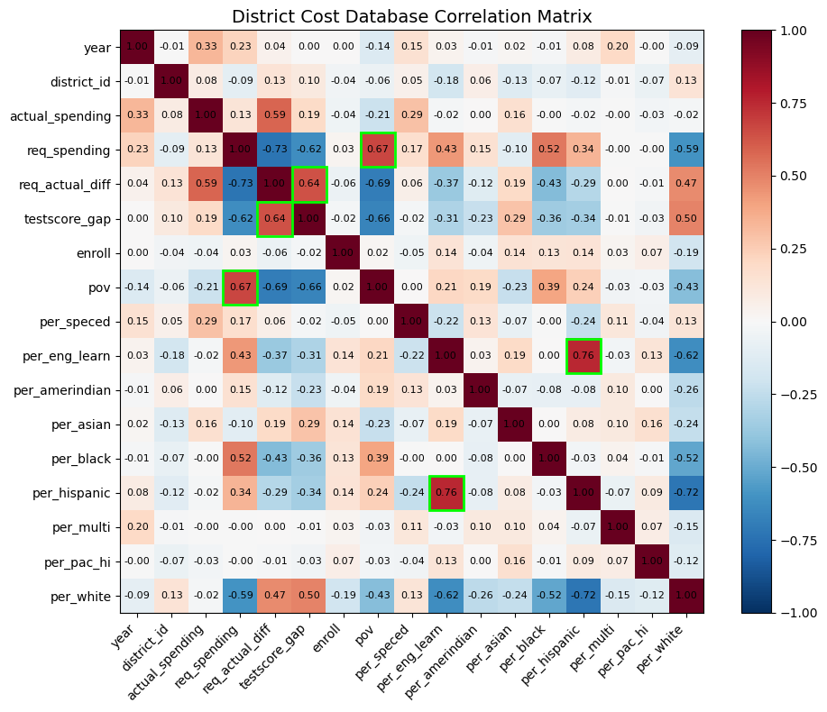

```python
# note that the cost difference between requested and actual spending correlates relatively highly with the test score gap
# this might be useful for further analysis
# for instance, could this be due to the specific district's characteristics?

# also note that the percent of ELL highly correlates to the percent of Hispanic students, this
# might be due to a large number of ELL students being Hispanic and may require further analysis

# Add text annotations and highlight specific cells
plt.figure(figsize=(10, 8))
dcd25_cmap = plt.cm.RdBu_r

im = plt.imshow(dcd25_correlation_matrix, cmap=dcd25_cmap, vmin=-1, vmax=1)
plt.colorbar(im)

# Add text annotations
for i in range(len(dcd25_numeric_columns)):
    for j in range(len(dcd25_numeric_columns)):
        text = plt.text(j, i, f'{dcd25_correlation_matrix.iloc[i, j]:.2f}',
                       ha="center", va="center", color="black", fontsize=8)

# Find and highlight only high POSITIVE correlation points (excluding diagonal)
correlation_threshold = 0.6  # Adjust this value as needed
highlight_points = []
for i in range(len(dcd25_numeric_columns)):
    for j in range(len(dcd25_numeric_columns)):
        # Removed abs() to only highlight positive correlations
        if i != j and dcd25_correlation_matrix.iloc[i, j] > correlation_threshold:
            highlight_points.append((i, j))

# Highlight the high correlation points with rectangles
for row, col in highlight_points:
    rect = plt.Rectangle((col - 0.5, row - 0.5), 1, 1, fill=False,
                         edgecolor='lime', linewidth=2)
    plt.gca().add_patch(rect)

plt.title('District Cost Database Correlation Matrix', fontsize=14)
plt.xticks(np.arange(len(dcd25_numeric_columns)), dcd25_numeric_columns, rotation=45, ha='right')
plt.yticks(np.arange(len(dcd25_numeric_columns)), dcd25_numeric_columns)
plt.tight_layout()
plt.show()
```

#### Do you need to modify or correct the data in some way?

Corrected it by removing some columns and recoding some others

#### Is there any class imbalance? (Categories that have many more items than other categories).

Almost all categories have more unique values than other columns. for instance region4 has 4 unique values while region9 has 9 unique vbaluees, and stabbr has over 50 unique values.

#### encode categorical data using one-hat encoding

```python
dfnew_encoded = pd.get_dummies(dfnew, drop_first=True)
dfnew_encoded.sample(10)
```

|  | year | statefip | region4 | region9 | effort | inc_effort | predicted_fedrevpp0_ | predicted_fedrevpp10_ | predicted_fedrevpp20_ | predicted_fedrevpp30_ | ... | ftotinc_over185pov | ftotinc_under130pov | ftotinc_over130pov | inc_gap185_ratio | inc_gap130_ratio | coverage | state_chartershare | inc_pubsch | inc_nonpubsch | pubprv_incratio |
| --- | --- | --- | --- | --- | --- | --- | --- | --- | --- | --- | --- | --- | --- | --- | --- | --- | --- | --- | --- | --- | --- |
| 343 | 2016 | 41 | 4 | 6 | 0.034619 | 0.039239 | 379.15340 | 637.7209 | 1072.6210 | 1804.1060 | ... | 130846.50 | 22198.60 | 119171.30 | 0.227009 | 0.186275 | 0.884384 | 0.054783 | 101964.70 | 127106.90 | 0.802197 |
| 1493 | 1993 | 18 | 2 | 1 | 0.015759 | 0.048040 | 1094.75100 | 1971.0600 | 3548.8230 | 6389.5280 | ... | 64123.15 | 18092.64 | 114555.60 | 0.088856 | 0.056240 | 0.878229 | 0.000000 | 39960.21 | 48956.75 | 0.252707 |
| 1501 | 1993 | 26 | 2 | 1 | 0.015759 | 0.048040 | 92.11819 | 154.7730 | 260.0429 | 436.9128 | ... | 64123.15 | 18092.64 | 114555.60 | 0.088856 | 0.056240 | 0.878229 | 0.000000 | 39960.21 | 48956.75 | 0.252707 |
| 733 | 2008 | 23 | 1 | 5 | 0.044833 | 0.047218 | 392.16340 | 676.4376 | 1166.7790 | 2012.5620 | ... | 89023.48 | 17640.55 | 80172.30 | 0.284247 | 0.220033 | 0.885279 | 0.000000 | 67958.51 | 78045.65 | 0.870753 |
| 306 | 2016 | 1 | 3 | 2 | 0.037601 | 0.040669 | 392.86310 | 601.5347 | 921.0436 | 1410.2610 | ... | 108585.60 | 18548.46 | 96805.30 | 0.231956 | 0.191606 | 0.862077 | 0.000000 | 75033.95 | 118145.10 | 0.635100 |
| 26 | 2022 | 30 | 4 | 4 | 0.035601 | 0.034384 | 955.72990 | 1962.3050 | 4029.0070 | 8272.3610 | ... | 137537.10 | 24992.31 | 125049.40 | 0.262109 | 0.199859 | 0.850845 | 0.000000 | 110318.90 | 109941.60 | 1.003432 |
| 645 | 2010 | 37 | 3 | 7 | 0.032764 | 0.039866 | 583.98410 | 839.9977 | 1208.2450 | 1737.9300 | ... | 99155.93 | 17450.03 | 87616.51 | 0.241113 | 0.199164 | 0.893103 | 0.026949 | 68898.66 | 111334.10 | 0.618846 |
| 1364 | 1996 | 42 | 1 | 3 | 0.015759 | 0.048040 | 74.00359 | 150.3090 | 305.2931 | 620.0818 | ... | 64123.15 | 18092.64 | 114555.60 | 0.088856 | 0.056240 | 0.878229 | 0.000000 | 39960.21 | 48956.75 | 0.252707 |
| 850 | 2006 | 38 | 2 | 9 | 0.037239 | 0.045120 | 322.57940 | 728.0143 | 1643.0210 | 3708.0570 | ... | 80610.27 | 16850.91 | 73123.89 | 0.328217 | 0.230443 | 0.898160 | 0.000000 | 65704.34 | 95554.90 | 0.687608 |
| 1500 | 1993 | 25 | 1 | 5 | 0.015759 | 0.048040 | 110.49840 | 194.5478 | 342.5287 | 603.0697 | ... | 64123.15 | 18092.64 | 114555.60 | 0.088856 | 0.056240 | 0.878229 | 0.000000 | 39960.21 | 48956.75 | 0.252707 |

10 rows × 118 columns

```python
dcd_encoded = pd.get_dummies(dcd25_renamed, drop_first=True)
dcd_encoded.sample(10)
```

|  | year | district_id | actual_spending | req_spending | req_actual_diff | testscore_gap | enroll | pov | per_speced | per_eng_learn | ... | stabbr_SD | stabbr_TN | stabbr_TX | stabbr_UT | stabbr_VA | stabbr_VT | stabbr_WA | stabbr_WI | stabbr_WV | stabbr_WY |
| --- | --- | --- | --- | --- | --- | --- | --- | --- | --- | --- | --- | --- | --- | --- | --- | --- | --- | --- | --- | --- | --- |
| 7884 | 2022 | 3819290 | 14241 | 10255 | 3986 | NaN | 345 | 0.084112 | 0.107246 | 0.000000 | ... | False | False | False | False | False | False | False | False | False | False |
| 36542 | 2019 | 606480 | 11885 | 7998 | 3887 | 0.860833 | 3510 | 0.039631 | 0.079202 | 0.168091 | ... | False | False | False | False | False | False | False | False | False | False |
| 143376 | 2011 | 4219140 | 10509 | 7739 | 2770 | 0.194979 | 1677 | 0.128480 | 0.177102 | 0.001193 | ... | False | False | False | False | False | False | False | False | False | False |
| 33609 | 2020 | 4400840 | 14347 | 17149 | -2802 | NaN | 8784 | 0.177701 | 0.197177 | 0.131717 | ... | False | False | False | False | False | False | False | False | False | False |
| 131383 | 2012 | 4666930 | 7284 | 7313 | -29 | 0.073804 | 1983 | 0.131163 | 0.124054 | 0.008573 | ... | True | False | False | False | False | False | False | False | False | False |
| 132227 | 2012 | 4833840 | 8640 | 10712 | -2072 | -0.004789 | 903 | 0.185053 | 0.116279 | 0.047619 | ... | False | False | True | False | False | False | False | False | False | False |
| 85581 | 2015 | 637260 | 11207 | 12798 | -1591 | NaN | 1101 | 0.168972 | 0.088102 | 0.012716 | ... | False | False | False | False | False | False | False | False | False | False |
| 21511 | 2021 | 4222590 | 15917 | 7961 | 7956 | NaN | 3793 | 0.080165 | 0.157395 | 0.013182 | ... | False | False | False | False | False | False | False | False | False | False |
| 89851 | 2015 | 2910770 | 8251 | 8555 | -304 | 0.004143 | 2111 | 0.222168 | 0.134060 | 0.001895 | ... | False | False | False | False | False | False | False | False | False | False |
| 10927 | 2022 | 4843110 | 21768 | 19164 | 2604 | NaN | 138 | 0.130435 | 0.188406 | 0.011217 | ... | False | False | True | False | False | False | False | False | False | False |

10 rows × 12375 columns

# 4. Storytelling With Data graph

Just like last week: choose any graph in the Introduction of Storytelling With Data. Use matplotlib to reproduce it in a rough way. I don't expect you to spend an enormous amount of time on this; I understand that you likely will not have time to re-create every feature of the graph. However, if you're excited about learning to use matplotlib, this is a good way to do that. You don't have to duplicate the exact values on the graph; just the same rough shape will be enough. If you don't feel comfortable using matplotlib yet, do the best you can and write down what you tried or what Google searches you did to find the answers.

#### Create the data in python from excel

```python
import pandas as pd

data = {
    'Month': ['Jan', 'Feb', 'Mar', 'Apr', 'May', 'Jun', 'Jul', 'Aug', 'Sep', 'Oct', 'Nov', 'Dec'],
    'Ticket Volume Received': [160, 184, 241, 149, 180, 161, 132, 202, 160, 139, 149, 177],
    'Ticket Volume Processed': [160, 184, 237, 148, 181, 150, 123, 156, 126, 104, 124, 140]
}

df_STD_week2 = pd.DataFrame(data)
print(df_STD_week2)
```

```
   Month  Ticket Volume Received  Ticket Volume Processed
0    Jan                     160                      160
1    Feb                     184                      184
2    Mar                     241                      237
3    Apr                     149                      148
4    May                     180                      181
5    Jun                     161                      150
6    Jul                     132                      123
7    Aug                     202                      156
8    Sep                     160                      126
9    Oct                     139                      104
10   Nov                     149                      124
11   Dec                     177                      140
```

#### create similar plot

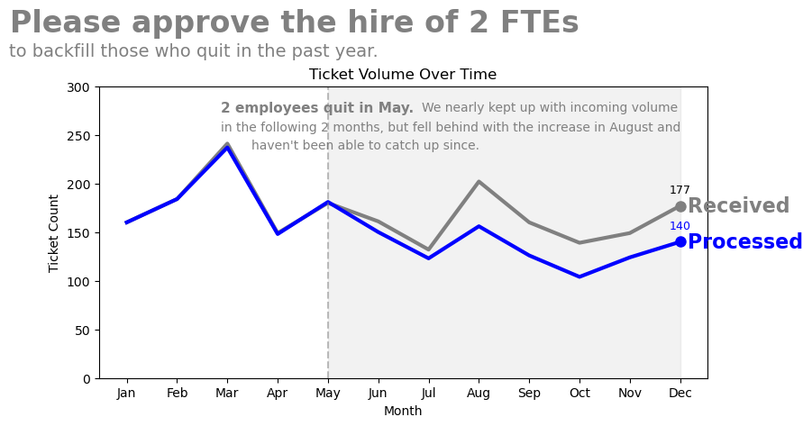

[output not shown]

```python
# Line chart comparing received vs processed ticket volumes
import matplotlib.pyplot as plt

months = df_STD_week2['Month']
received = df_STD_week2['Ticket Volume Received']
processed = df_STD_week2['Ticket Volume Processed']

fig, ax = plt.subplots(figsize=(9, 5))
ax.plot(months, received, color='grey', label='Received', linewidth=3)
ax.plot(months, processed, color='blue', label='Processed', linewidth=3)
ax.set_title('Ticket Volume Over Time')
ax.set_xlabel('Month')
ax.set_ylabel('Ticket Count')
ax.set_ylim(0, 300)
ax.grid(False)

# Put labels at the end of each line
ax.annotate("Received", xy=(months.iloc[-1], received.iloc[-1]),
            xytext=(6, 0), textcoords='offset points', va='center', color='grey', fontsize=16, fontweight='bold')
ax.annotate("Processed", xy=(months.iloc[-1], processed.iloc[-1]),
            xytext=(6, 0), textcoords='offset points', va='center', color='blue', fontsize=16, fontweight='bold')

# Text to display at the top
top_text = 'Please approve the hire of 2 FTEs'
top_text2 = 'to backfill those who quit in the past year.'
explanation_text = '2 employees quit in May.'
explanation_text2 = 'We nearly kept up with incoming volume'
explanation_text3 = 'in the following 2 months, but fell behind with the increase in August and'
explanation_text4 = 'haven\'t been able to catch up since.'

# Annotations explaining the trend
ax.text(0.2, 0.95, explanation_text, transform=ax.transAxes, fontsize=11,
         verticalalignment='top', weight='bold', color='grey')
ax.text(0.53, 0.95, explanation_text2, transform=ax.transAxes, fontsize=10,
         verticalalignment='top', color='grey')
ax.text(0.2, 0.88, explanation_text3, transform=ax.transAxes, fontsize=10,
         verticalalignment='top', color='grey')
ax.text(0.25, 0.82, explanation_text4, transform=ax.transAxes, fontsize=10,
         verticalalignment='top', color='grey')

# Annotations at specific points
ax.annotate(f"{received.iloc[11]}", xy=(months.iloc[11], received.iloc[11]),
            xytext=(0, 10), textcoords='offset points', ha='center', fontsize=9)
ax.annotate(f"{processed.iloc[11]}", xy=(months.iloc[11], processed.iloc[11]),
            xytext=(0, 10), textcoords='offset points', ha='center', fontsize=9, color='blue')

# Add dots at the end of each line
ax.plot(months.iloc[-1], received.iloc[-1], 'o', color='grey', markersize=8)
ax.plot(months.iloc[-1], processed.iloc[-1], 'o', color='blue', markersize=8)

# Highlight period of disruption
disruption_start = 4  # May (index 4)
ax.axvline(x=disruption_start, color='grey', linestyle='--', alpha=0.5)

# Shaded area where differences occur
ax.axvspan(4, 11, alpha=0.1, color='grey', label='dropping volume period')

# Text at the top
ax.text(9, 380, top_text,fontsize=24, ha='right', va='top', color='grey', weight='bold')
ax.text(5, 345, top_text2,fontsize=14, ha='right', va='top', color='grey')

# ax.legend()
fig.tight_layout()
plt.savefig('STD2_ticket_volume_comparison.png', dpi=300, bbox_inches='tight')
plt.show()
plt.close()
```